# Protocols code

Chananchida Sang-aram & Ruth Seurinck

2023-10-25

# Materials

## Equipment setup

### Input data

To follow the procedure below, users must provide a Seurat object (version ≥3) containing the gene expression matrix and cell type annotations. Nevertheless, this pipeline can be easily adapted to work with expression data stored in other formats (see Troubleshooting). The data should be preprocessed appropriately for differential expression analysis, such as through quality control, normalization and batch correction.

### Hardware

Windows, Linux or macOS

### Software

R (RStudio is recommended)

NicheNet can be installed by running the following command in R:

```r
if (!requireNamespace("devtools", quietly=TRUE))
  install.packages("devtools")

devtools::install_github("saeyslab/nichenetr")
```

### Example data

As example expression data of interacting cells, we will use mouse NICHE-seq data from Medaglia et al. (2017) to explore intercellular communication in the T cell area in the inguinal lymph node before and 72 hours after lymphocytic choriomeningitis virus (LCMV) infection. Specifically, we will prioritize which ligands can best explain the downstream changes after LCMV infection in CD8 T cells as the receiver population. This dataset contains 13,541 genes and 5,027 cells from 6 cell populations: CD4 T cells (including regulatory T cells), CD8 T cells, B cells, natural killer (NK) cells, dendritic cells (DCs) and inflammatory monocytes.

Download the data by clicking ‘seuratObj.rds’ at https://zenodo.org/record/353188941. To download the file with the command line, use commands such as wget or curl (Linux/macOS):

`wget https://zenodo.org/record/3531889/files/seuratObj.rds`

To download the file within the R session, entering the following commands:

```r
options(timeout = 3600) # increase time limit for downloading the data
seuratObj <- readRDS(url("https://zenodo.org/record/3531889/files/seuratObj.rds"))
```

If the file is downloaded within the R session, it will have to be downloaded again once the session is restarted.

### Human/Mouse networks

Three networks are required to run the NicheNet analysis: the ligand-target prior model, the ligand-receptor network, and the weighted ligand-receptor network. We provide these networks with either human or mouse gene symbols and they can be downloaded at https://zenodo.org/record/7074291/. This repository also contains other networks not used in the main analysis but in an additional visualization step (Step 31) and during model construction (Box 3). As with the example data, they can be downloaded locally through the website or command line, or in the R session. We recommend users to download them locally for convenience.

#### Downloading data locally

```r
ZENODO_PATH=https://zenodo.org/record/7074291/files

# Human ligand-target, ligand-receptor, and weighted networks
wget $ZENODO_PATH/ligand_target_matrix_nsga2r_final.rds
wget $ZENODO_PATH/lr_network_human_21122021.rds
wget $ZENODO_PATH/weighted_networks_nsga2r_final.rds

# Mouse ligand-target, ligand-receptor, and weighted networks
wget $ZENODO_PATH/ligand_target_matrix_nsga2r_final_mouse.rds
wget $ZENODO_PATH/lr_network_mouse_21122021.rds
wget $ZENODO_PATH/weighted_networks_nsga2r_final_mouse.rds
```

#### Download the file in the R session, mouse example

```r
zenodo_path <- "https://zenodo.org/record/7074291/files/"

ligand_target_matrix <- readRDS(url(paste0(zenodo_path, "ligand_target_matrix_nsga2r_final_mouse.rds")))
lr_network <- readRDS(url(paste0(zenodo_path, "lr_network_mouse_21122021.rds")))
weighted_networks <- readRDS(url(paste0(zenodo_path, "weighted_networks_nsga2r_final_mouse.rds")))


ligand_target_matrix[1:5, 1:5] # target genes in rows, ligands in columns
```

```
##               2300002M23Rik 2610528A11Rik 9530003J23Rik            a
## 0610005C13Rik  0.000000e+00  0.000000e+00  1.311297e-05 0.000000e+00
## 0610009B22Rik  0.000000e+00  0.000000e+00  1.269301e-05 0.000000e+00
## 0610009L18Rik  8.872902e-05  4.977197e-05  2.581909e-04 7.570125e-05
## 0610010F05Rik  2.194046e-03  1.111556e-03  3.142374e-03 1.631658e-03
## 0610010K14Rik  2.271606e-03  9.360769e-04  3.546140e-03 1.697713e-03
##                        A2m
## 0610005C13Rik 1.390053e-05
## 0610009B22Rik 1.345536e-05
## 0610009L18Rik 9.802264e-05
## 0610010F05Rik 2.585820e-03
## 0610010K14Rik 2.632082e-03
```

```r
head(lr_network)
```

```
##            from    to database   source
## 1 2300002M23Rik  Ddr1 omnipath omnipath
## 2 2610528A11Rik Gpr15 omnipath omnipath
## 3 9530003J23Rik Itgal omnipath omnipath
## 4             a  Atrn omnipath omnipath
## 5             a  F11r omnipath omnipath
## 6             a  Mc1r omnipath omnipath
```

```r
head(weighted_networks$lr_sig) # interactions and their weights in the ligand-receptor + signaling network
```

```
##            from     to     weight
## 1 0610010F05Rik    App 0.10989552
## 2 0610010F05Rik    Cat 0.06732398
## 3 0610010F05Rik   H1f2 0.06601048
## 4 0610010F05Rik Lrrc49 0.08288421
## 5 0610010F05Rik  Nicn1 0.08639550
## 6 0610010F05Rik  Srpk1 0.12290087
```

# Procedure

Here, we describe the procedure for both the sender-focused and sender-agnostic approach, as shown here:

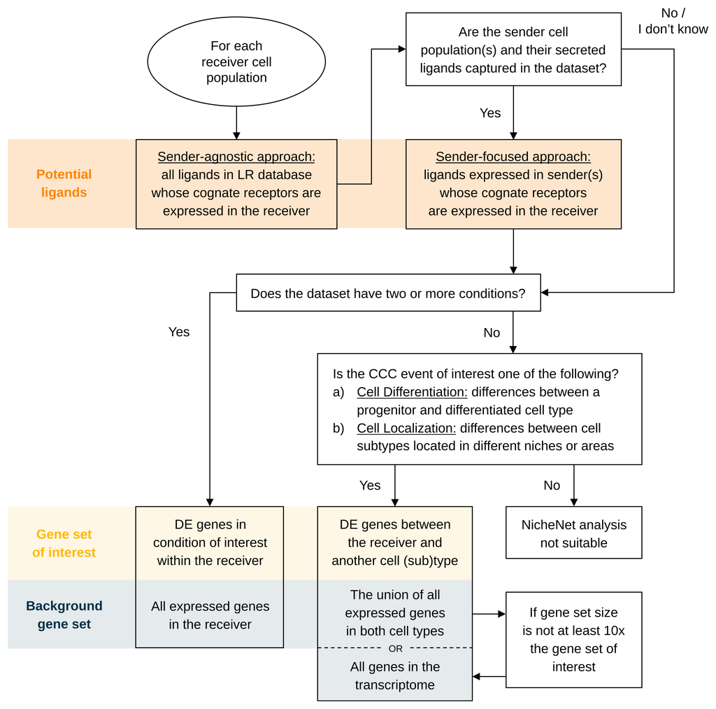

As two conditions are present in this example dataset (steady state and 3 days after LCMV infection), the gene set of interest is chosen as the DE genes between these conditions in the receiver cell type. Box 4 details the use of wrapper functions that can automatically run Steps 5-24 (without Step 15).

## Feature extraction

1. Load required libraries.

```r
library(nichenetr)
library(Seurat)
library(tidyverse)
```

2. *(Optional)* For older Seurat objects, update it to be compatible with the currently installed Seurat version. For expression data with older gene symbols, convert them to more recent gene symbols. When analyzing a human dataset, change the second argument to “human”. Aside from downloading the correct networks, this is the only point in the analysis where the code differs between human and mouse datasets.

```r
seuratObj <- UpdateSeuratObject(seuratObj)
seuratObj <- alias_to_symbol_seurat(seuratObj, "mouse")

seuratObj
```

```
## An object of class Seurat
## 13541 features across 5027 samples within 1 assay
## Active assay: RNA (13541 features, 1575 variable features)
##  3 layers present: counts, data, scale.data
##  4 dimensional reductions calculated: cca, cca.aligned, tsne, pca
```

3. Set the cell type annotation column as the identity of the Seurat object.

```r
Idents(seuratObj) <- seuratObj$celltype
```

4. Define a “receiver” cell population. The receiver cell population can only consist of one cell type.

```r
receiver <- "CD8 T"
```

5. Determine which genes are expressed in the receiver cell population. The function `get_expressed_genes` considers genes to be expressed if they have non-zero counts in a certain percentage of the cell population (by default set at 10%). Here, we have lowered the threshold to 5% (`pct`) as some of the ligands and receptors are very lowly expressed. Users are also free to define expressed genes differently in a way that fits their data.

```r
expressed_genes_receiver <- get_expressed_genes(receiver, seuratObj,  pct = 0.05)

# Preview
length(expressed_genes_receiver)
```

```
## [1] 3903
```

```r
head(expressed_genes_receiver)
```

```
## [1] "0610007C21Rik" "0610007L01Rik" "0610007P22Rik" "0610009D07Rik"
## [5] "0610010K14Rik" "0610012G03Rik"
```

6. Get a list of all receptors available in the ligand-receptor network, and define expressed receptors as genes that are in the ligand-receptor network and expressed in the receiver.

```r
all_receptors <- unique(lr_network$to)
expressed_receptors <- intersect(all_receptors, expressed_genes_receiver)

# Preview
length(expressed_receptors)
```

```
## [1] 107
```

```r
head(expressed_receptors)
```

```
## [1] "Itgal"   "Notch1"  "Tspan14" "Itga4"   "Itgb1"   "Il6ra"
```

7. Define the potential ligands as all ligands whose cognate receptors are expressed.

```r
potential_ligands <- lr_network[lr_network$to %in% expressed_receptors, ]
potential_ligands <- unique(potential_ligands$from)

# Preview
length(potential_ligands)
```

```
## [1] 475
```

```r
head(potential_ligands)
```

```
## [1] "9530003J23Rik" "Adam10"        "Adam11"        "Adam12"
## [5] "Adam15"        "Adam17"
```

8. *(Optional)* For the sender-focused approach, define sender cell types and expressed genes in all populations combined. Then, filter potential ligands to those that are expressed in sender cells.

```r
sender_celltypes <- c("CD4 T", "Treg", "Mono", "NK", "B", "DC")
list_expressed_genes_sender <- lapply(sender_celltypes, function(celltype) {
    get_expressed_genes(celltype, seuratObj, pct = 0.05)
  })
expressed_genes_sender <- unique(unlist(list_expressed_genes_sender))
potential_ligands_focused <- intersect(potential_ligands, expressed_genes_sender)

# Preview
length(expressed_genes_sender)
```

```
## [1] 8492
```

```r
head(expressed_genes_sender)
```

```
## [1] "0610007C21Rik" "0610007L01Rik" "0610009D07Rik" "0610010K14Rik"
## [5] "0610012G03Rik" "1110002B05Rik"
```

```r
length(potential_ligands_focused)
```

```
## [1] 122
```

```r
head(potential_ligands_focused)
```

```
## [1] "Adam10" "Adam15" "Adam17" "Adam9"  "Alcam"  "Apoe"
```

9. Define the reference condition and condition of interest. The condition of interest is the condition after the CCC event has taken place, or the ‘case’ group in case-control studies. Here, it represents the condition after LCMV infection. Similarly, the reference condition is the state before the CCC event, often referred to as the control or steady-state condition.

```r
condition_oi <- "LCMV"
condition_reference <- "SS"
```

10. Define the gene set of interest that represents the cell-cell communication event to be studied. First, create a new Seurat object that only contains the receiver cell type. Then, perform DE analysis between the treatment conditions within the receiver cell type. Finally, define the gene set of interest as significantly DE genes (i.e., genes with adjusted p-value lower than or equal to 0.05 and absolute log-fold change greater than 0.25).

By default, both genes that are up and downregulated are considered. Users can choose to focus on only one direction (typically upregulation) by removing the `abs()` function and adjusting the equality term to either >= 0.25 or <= -0.25 for up and downregulation, respectively. We recommend the gene set of interest to contain between 20 and 2000 genes for optimal ligand activity prediction. Moreover, the number of background genes should be sufficiently greater than those of the gene set of interest.

```r
seurat_obj_receiver <- subset(seuratObj, idents = receiver)
DE_table_receiver <- FindMarkers(object = seurat_obj_receiver,
                                 ident.1 = condition_oi,
                                 ident.2 = condition_reference,
                                 group.by = "aggregate",
                                 min.pct = 0.05)

geneset_oi <- DE_table_receiver[DE_table_receiver$p_val_adj <= 0.05 &
                                  abs(DE_table_receiver$avg_log2FC) >= 0.25, ]
geneset_oi <- rownames(geneset_oi)[rownames(geneset_oi) %in% rownames(ligand_target_matrix)]

# Preview
length(geneset_oi)
```

```
## [1] 241
```

```r
head(geneset_oi)
```

```
## [1] "Ifi27l2b" "Irf7"     "Ly6a"     "Stat1"    "Ly6c2"    "Ifit3"
```

11. Determine background genes as all the genes expressed in the receiver cell type that are also in the ligand-target matrix.

```r
background_expressed_genes <- expressed_genes_receiver[
  expressed_genes_receiver %in% rownames(ligand_target_matrix)]

# Preview
length(background_expressed_genes)
```

```
## [1] 3182
```

```r
head(background_expressed_genes)
```

```
## [1] "0610010K14Rik" "0610012G03Rik" "1110004F10Rik" "1110038B12Rik"
## [5] "1110038F14Rik" "1600014C10Rik"
```

## Ligand activity analysis and downstream prediction

12. Perform the ligand activity analysis, then sort the ligands based on the area under the precision-recall curve (AUPR).

```r
ligand_activities <- predict_ligand_activities(
  geneset = geneset_oi,
  background_expressed_genes = background_expressed_genes,
  ligand_target_matrix = ligand_target_matrix,
  potential_ligands = potential_ligands)

ligand_activities <- ligand_activities[order(ligand_activities$aupr_corrected,
                                             decreasing = TRUE), ]

# Preview
dim(ligand_activities)
```

```
## [1] 475   5
```

```r
head(ligand_activities)
```

```
## # A tibble: 6 × 5
##   test_ligand auroc  aupr aupr_corrected pearson
##   <chr>       <dbl> <dbl>          <dbl>   <dbl>
## 1 Ifna1       0.713 0.418          0.342   0.483
## 2 Ifnl3       0.682 0.392          0.316   0.431
## 3 Ifnb1       0.708 0.387          0.312   0.418
## 4 Il27        0.676 0.378          0.303   0.433
## 5 Ifng        0.725 0.366          0.290   0.434
## 6 Ifnk        0.669 0.275          0.200   0.268
```

13. *(Optional)* If performing the sender-focused approach, subset the ligand activities to only contain expressed ligands. **Note:** When using the sender-agnostic approach, simply replace `ligand_activities` with `ligand_activities_all` in Steps 14 and 18.

```r
ligand_activities_all <- ligand_activities
ligand_activities <- ligand_activities[ligand_activities$test_ligand %in%
                                         potential_ligands_focused, ]

# Preview
dim(ligand_activities)
```

```
## [1] 122   5
```

```r
head(ligand_activities)
```

```
## # A tibble: 6 × 5
##   test_ligand auroc  aupr aupr_corrected pearson
##   <chr>       <dbl> <dbl>          <dbl>   <dbl>
## 1 Il27        0.676 0.378          0.303   0.433
## 2 Ebi3        0.660 0.255          0.179   0.248
## 3 Tnf         0.668 0.203          0.127   0.240
## 4 Ptprc       0.659 0.193          0.117   0.162
## 5 H2-Eb1      0.655 0.188          0.112   0.175
## 6 H2-M3       0.634 0.188          0.112   0.187
```

14. Obtain the names of the top 30 ligands.

```r
best_upstream_ligands <- top_n(ligand_activities, 30, aupr_corrected)$test_ligand

# Preview
length(best_upstream_ligands)
```

```
## [1] 30
```

```r
head(best_upstream_ligands)
```

```
## [1] "Il27"   "Ebi3"   "Tnf"    "Ptprc"  "H2-Eb1" "H2-M3"
```

15. *(Optional)* Assess the quality of predicted ligands according to Box 5.
16. Infer which genes in the gene set of interest have the highest regulatory potential for each top-ranked ligand. The function `get_weighted_ligand_target_links` will return genes that are in the gene set of interest and are the top `n` targets of a ligand (default: `n = 250`).

```r
active_ligand_target_links_df <- lapply(best_upstream_ligands,
                                        get_weighted_ligand_target_links,
                                        geneset = geneset_oi,
                                        ligand_target_matrix = ligand_target_matrix,
                                        n = 200)

active_ligand_target_links_df <- drop_na(bind_rows(active_ligand_target_links_df))

# Preview
dim(active_ligand_target_links_df)
```

```
## [1] 588   3
```

```r
head(active_ligand_target_links_df)
```

```
## # A tibble: 6 × 3
##   ligand target weight
##   <chr>  <chr>   <dbl>
## 1 Il27   Adar    0.163
## 2 Il27   B2m     0.170
## 3 Il27   Bst2    0.111
## 4 Il27   Cd274   0.111
## 5 Il27   Cxcl10  0.178
## 6 Il27   Cxcr4   0.178
```

17. Similarly, identify which receptors have the highest interaction potential with the top-ranked ligands.

```r
ligand_receptor_links_df <- get_weighted_ligand_receptor_links(
  best_upstream_ligands = best_upstream_ligands,
  expressed_receptors = expressed_receptors,
  lr_network = lr_network,
  weighted_networks_lr_sig = weighted_networks$lr_sig
)

# Preview
dim(ligand_receptor_links_df)
```

```
## [1] 54  3
```

```r
head(ligand_receptor_links_df)
```

```
## # A tibble: 6 × 3
##   from   to     weight
##   <chr>  <chr>   <dbl>
## 1 Adam17 Il6ra   0.447
## 2 Adam17 Itgb1   0.454
## 3 Adam17 Notch1  1.05
## 4 App    Cd74    0.670
## 5 App    Sorl1   0.922
## 6 Ccl22  Ccr7    0.679
```

## Visualizations

18. Create a heatmap of the ligand activity measure (Figure 3a).

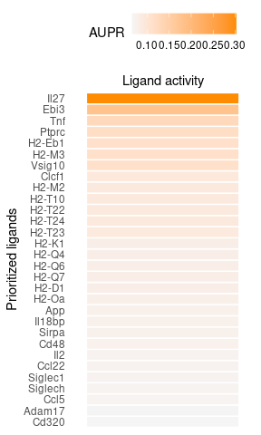

```r
ligand_aupr_matrix <- column_to_rownames(ligand_activities, "test_ligand")
ligand_aupr_matrix <- ligand_aupr_matrix[rev(best_upstream_ligands), "aupr_corrected", drop=FALSE]
vis_ligand_aupr <- as.matrix(ligand_aupr_matrix, ncol = 1)

(make_heatmap_ggplot(vis_ligand_aupr,
                     y_name = "Prioritized ligands", x_name = "Ligand activity",
                     legend_title = "AUPR", color = "darkorange") +
    theme(axis.text.x.top = element_blank()))
```

19. Prepare the weighted ligand-target data frame for visualization by transforming it into matrix. By default, regulatory potentials lower than the 25th percentile are set to zero for visualization clarity. This cutoff parameter can freely be tuned by the user.

```r
active_ligand_target_links <- prepare_ligand_target_visualization(
  ligand_target_df = active_ligand_target_links_df,
  ligand_target_matrix = ligand_target_matrix,
  cutoff = 0.25)
```

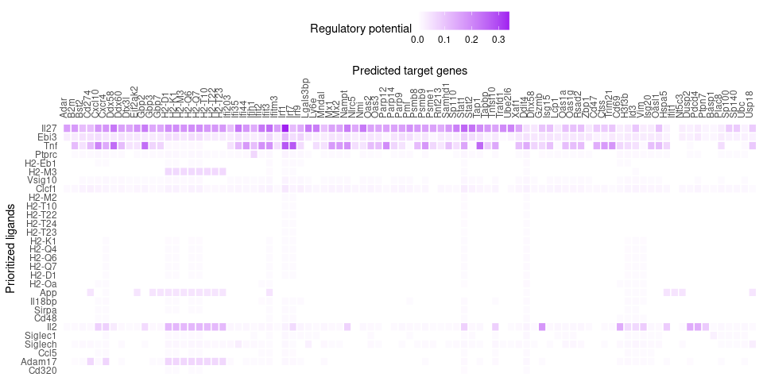

```r
order_ligands <- rev(intersect(best_upstream_ligands, colnames(active_ligand_target_links)))
order_targets <- intersect(unique(active_ligand_target_links_df$target), rownames(active_ligand_target_links))

vis_ligand_target <- t(active_ligand_target_links[order_targets,order_ligands])

(make_heatmap_ggplot(vis_ligand_target,
                     y_name = "Prioritized ligands", x_name = "Predicted target genes",
                     color = "purple", legend_title = "Regulatory potential") +
    scale_fill_gradient2(low = "whitesmoke",  high = "purple"))
```

21. Create a heatmap for ligand-receptor interactions (Figure 3c).

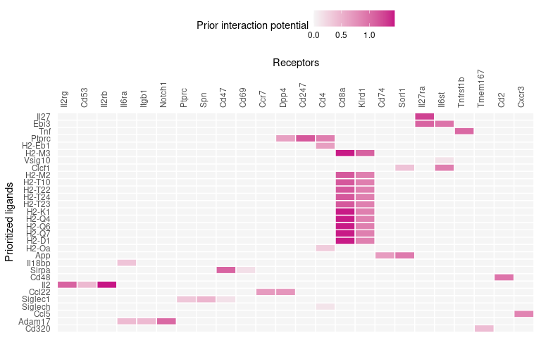

```r
vis_ligand_receptor_network <- prepare_ligand_receptor_visualization(
  ligand_receptor_links_df, best_upstream_ligands,
  order_hclust = "receptors")

(make_heatmap_ggplot(t(vis_ligand_receptor_network),
                     y_name = "Prioritized ligands", x_name = "Receptors",
                     color = "mediumvioletred", legend_title = "Prior interaction potential"))
```

22. For each cell type, compute the log-fold change of the top-ranked ligands between treatment conditions.

```r
celltype_order <- levels(Idents(seuratObj))

DE_table_top_ligands <- lapply(
  celltype_order[celltype_order %in% sender_celltypes],
  get_lfc_celltype,
  seurat_obj = seuratObj,
  condition_colname = "aggregate",
  condition_oi = condition_oi,
  condition_reference = condition_reference,
  celltype_col = "celltype",
  min.pct = 0, logfc.threshold = 0,
  features = best_upstream_ligands
)

DE_table_top_ligands <- reduce(DE_table_top_ligands, full_join)
DE_table_top_ligands <- column_to_rownames(DE_table_top_ligands, "gene")
```

23. Create the heatmap (Figure 3d).

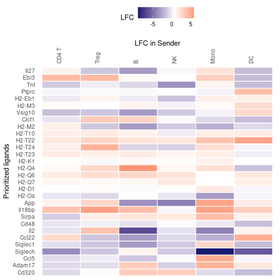

```r
vis_ligand_lfc <- as.matrix(DE_table_top_ligands[rev(best_upstream_ligands), , drop=FALSE])

(make_threecolor_heatmap_ggplot(vis_ligand_lfc,
                                y_name = "Prioritized ligands", x_name = "LFC in Sender",
                                low_color = "midnightblue", mid_color = "white",
                                mid = median(vis_ligand_lfc), high_color = "red",
                                legend_title = "LFC"))
```

24. Create a dot plot showing the average expression of ligands per cell type, as well as the percentage of cells from the cell type expressing the ligands (Figure 3e).

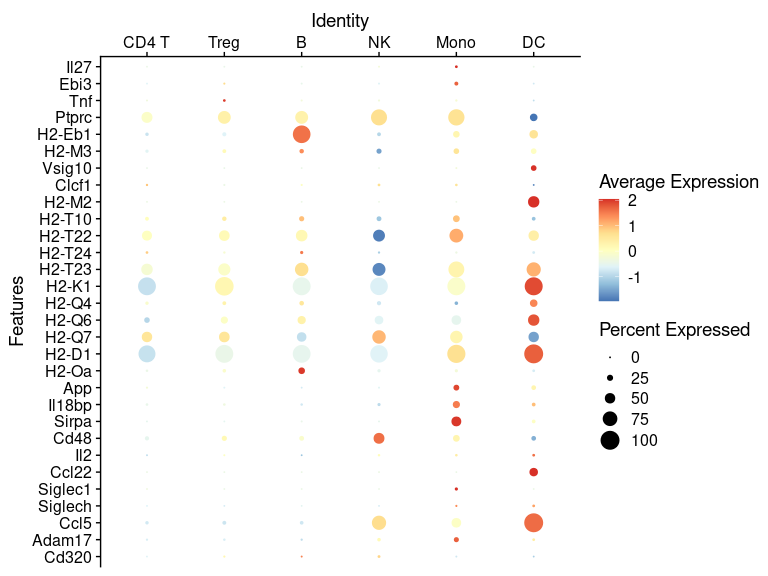

```r
DotPlot(subset(seuratObj, celltype %in% sender_celltypes),
        features = rev(best_upstream_ligands), cols = "RdYlBu") +
  coord_flip() +
  scale_y_discrete(position = "right")
```

25. Create a line plot comparing the rankings between the sender-agnostic and sender-focused approach (Figure 3f).

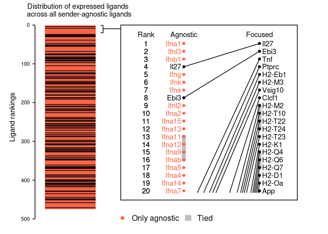

```r
(make_line_plot(ligand_activities = ligand_activities_all,
                potential_ligands = potential_ligands_focused) +
   theme(plot.title = element_text(size=11, hjust=0.1, margin=margin(0, 0, -5, 0))))
```

26. To create a ligand-target chord diagram, assign each ligand to a specific cell type. The aggregation and assignment functions can be specified through the `func.agg` and `func.assign` parameters. By default, these parameters are set to `mean` and `function(x) {mean(x)+sd(x)}`, respectively.

```r
ligand_type_indication_df <- assign_ligands_to_celltype(seuratObj, best_upstream_ligands[1:20], celltype_col = "celltype")

# Preview
dim(ligand_type_indication_df)
```

```
## [1] 20  2
```

```r
head(ligand_type_indication_df)
```

```
##   ligand_type ligand
## 1       CD8 T  Clcf1
## 2        Treg    Tnf
## 3           B H2-Eb1
## 4           B  H2-M3
## 5           B H2-T24
## 6           B  H2-Oa
```

```r
active_ligand_target_links_df$target_type <- "LCMV-DE"
circos_links <- get_ligand_target_links_oi(ligand_type_indication_df,
                                           active_ligand_target_links_df, cutoff = 0.75)
# Preview
dim(circos_links)
```

```
## [1] 149   5
```

```r
head(circos_links)
```

```
## # A tibble: 6 × 5
##   ligand target weight target_type ligand_type
##   <chr>  <chr>   <dbl> <chr>       <chr>
## 1 Il27   Adar    0.163 LCMV-DE     Mono
## 2 Il27   B2m     0.170 LCMV-DE     Mono
## 3 Il27   Bst2    0.111 LCMV-DE     Mono
## 4 Il27   Cd274   0.111 LCMV-DE     Mono
## 5 Il27   Cxcl10  0.178 LCMV-DE     Mono
## 6 Il27   Cxcr4   0.178 LCMV-DE     Mono
```

28. Assign colors to cell types and target gene groups. Then, prepare the data frame for visualization: the function assigns colors to ligands and targets and calculates gaps between sectors of the chord diagram.

```r
ligand_colors <- c("General" = "#377EB8", "NK" = "#4DAF4A", "B" = "#984EA3",
                   "Mono" = "#FF7F00", "DC" = "#FFFF33", "Treg" = "#F781BF",
                   "CD8 T"= "#E41A1C")
target_colors <- c("LCMV-DE" = "#999999")

vis_circos_obj <- prepare_circos_visualization(circos_links,
                                               ligand_colors = ligand_colors,
                                               target_colors = target_colors)
```

29. Draw the chord diagram (Figure 3g).

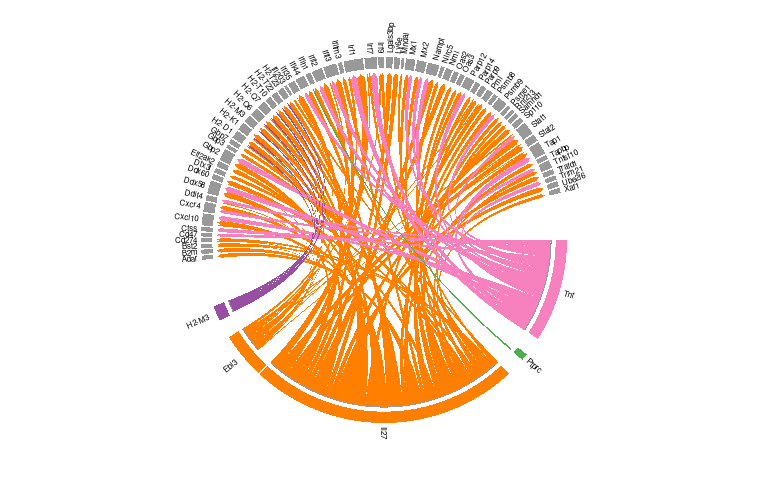

```r
make_circos_plot(vis_circos_obj, transparency = FALSE,  args.circos.text = list(cex = 0.5))
```

30. To create a ligand-receptor chord diagram, perform Steps 27-29 using the weighted ligand-receptor data frame from Step 17. Because `prepare_circos_visualization` accesses “target” and “target_type” columns, it is necessary to rename the columns accordingly even though the data frame contains receptor and not target gene information. When drawing the plot, the argument `link.visible = TRUE` is also necessary for making all links visible, since no cutoff is used to filter out ligand-receptor interactions.

```r
lr_network_top_df <- rename(ligand_receptor_links_df, ligand=from, target=to)
lr_network_top_df$target_type = "LCMV_CD8T_receptor"
lr_network_top_df <- inner_join(lr_network_top_df, ligand_type_indication_df)
receptor_colors <- c("LCMV_CD8T_receptor" = "#E41A1C")

vis_circos_receptor_obj <- prepare_circos_visualization(lr_network_top_df,
                                                        ligand_colors = ligand_colors,
                                                        target_colors = receptor_colors)
```

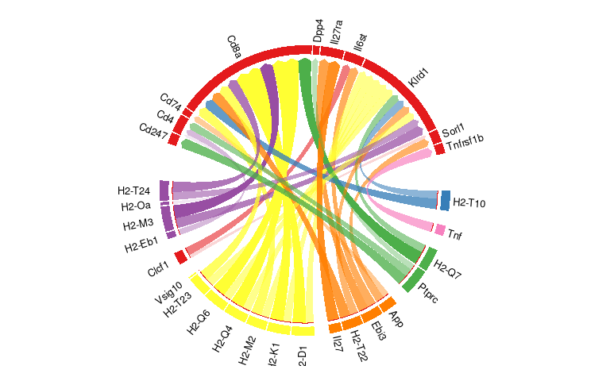

```r
make_circos_plot(vis_circos_receptor_obj, transparency = TRUE,
                 link.visible = TRUE,  args.circos.text = list(cex = 0.8))
```

31. To create a signaling graph, first download the ligand-transcription factor matrix. Then, extract the most highly weighted paths from the ligand to the target genes of interest. The number of regulators that are extracted can be adjusted using `top_n_regulators`. By setting `minmax_scaling = TRUE`, we perform min-max scaling to make the weights between the signaling and gene regulatory network more comparable. Additionally, it is possible to check which data sources support the inferred pathway by using the function `infer_supporting_datasources`. This would require separate signaling and gene regulatory networks as input (see Box 3 for code to download these networks).

```r
ligand_tf_matrix <- readRDS(url("https://zenodo.org/record/7074291/files/ligand_tf_matrix_nsga2r_final_mouse.rds"))
ligands_oi <- "Ebi3"
targets_oi <- c("Irf1", "Irf9")

active_signaling_network <- get_ligand_signaling_path(ligands_all = ligands_oi,
                                                      targets_all = targets_oi,
                                                      weighted_networks = weighted_networks,
                                                      ligand_tf_matrix = ligand_tf_matrix,
                                                      top_n_regulators = 4, minmax_scaling = TRUE)
```

32. Convert the data frames into a DiagrammeR object, and render the signaling graph (Figure 3h).

```r
signaling_graph <- diagrammer_format_signaling_graph(
  signaling_graph_list = active_signaling_network,
  ligands_all = ligands_oi, targets_all = targets_oi,
  sig_color = "indianred", gr_color = "steelblue")

DiagrammeR::render_graph(signaling_graph, layout = "tree")
```

[interactive chart not shown]

## Prioritization of ligand-receptor pairs

This section is only applicable for the sender-focused approach. Whereas Step 12 prioritizes ligands only on the basis of their activity through target gene expression, this section incorporates relative expression and differential expression to further prioritize LR pairs associated with specific sender and receiver cell types. To prioritize multiple receiver cell types, see Box 2.

33. Filter the ligand-receptor network to only contain expressed interactions.

```r
lr_network_filtered <- filter(lr_network, from %in% potential_ligands_focused &
                                to %in% expressed_receptors)[, c("from", "to")]
```

34. Calculate the values required for prioritization, including DE between cell types, average expression, and DE between conditions. To use the wrapper function, follow option A. To calculate these values step-by-step, follow option B.

A. **Using the wrapper function.**

1. Run the wrapper function. In case of steady-state datasets, use `scenario="one_condition"` and do not provide anything to the `condition_` arguments.

```r
info_tables <- generate_info_tables(
    seuratObj,
    celltype_colname = "celltype",
    senders_oi = sender_celltypes,
    receivers_oi = receiver,
    lr_network = lr_network_filtered,
    condition_colname = "aggregate",
    condition_oi = condition_oi,
    condition_reference = condition_reference,
    scenario = "case_control"
)
```

```
## condition_* is given. Only cells from that condition will be considered in cell type specificity calculation.
```

```
## As of Seurat v5, we recommend using AggregateExpression to perform pseudo-bulk analysis.
```

2. Assign the output of the wrapper function to variables.

```r
processed_DE_table <- info_tables$sender_receiver_de
processed_expr_table <- info_tables$sender_receiver_info
processed_condition_markers <- info_tables$lr_condition_de

# Preview
dim(processed_DE_table)
```

```
## [1] 1212   13
```

```r
head(processed_DE_table)
```

```
##   sender receiver ligand receptor lfc_ligand lfc_receptor
## 1     DC    CD8 T  H2-M2     Cd8a  11.002412    2.3838066
## 2     DC    CD8 T  H2-M2    Klrd1  11.002412    0.9199196
## 3     DC    CD8 T  Ccl22     Dpp4   9.920608    0.2991720
## 4     DC    CD8 T Vsig10    Il6st  10.070530    0.1411494
## 5     DC    CD8 T  Ccl22     Ccr7   9.920608    0.1468652
## 6     DC    CD8 T Cxcl16    Cxcr6   8.101436    1.8384579
##   ligand_receptor_lfc_avg  p_val_ligand  p_adj_ligand p_val_receptor
## 1                6.693109 1.017174e-272 1.377355e-268  5.250531e-206
## 2                5.961166 1.017174e-272 1.377355e-268   6.104465e-17
## 3                5.109890 1.590801e-296 2.154103e-292   6.628900e-04
## 4                5.105840 2.637179e-194 3.571005e-190   1.470347e-02
## 5                5.033737 1.590801e-296 2.154103e-292   5.070025e-05
## 6                4.969947 1.138617e-243 1.541801e-239   5.987787e-21
##   p_adj_receptor pct_expressed_sender pct_expressed_receiver
## 1  7.109745e-202                0.429                  0.659
## 2   8.266056e-13                0.429                  0.185
## 3   1.000000e+00                0.500                  0.148
## 4   1.000000e+00                0.286                  0.090
## 5   6.865321e-01                0.500                  0.320
## 6   8.108063e-17                0.929                  0.089
```

```r
dim(processed_expr_table)
```

```
## [1] 10045     7
```

```r
head(processed_expr_table)
```

```
## # A tibble: 6 × 7
##   sender receiver ligand receptor avg_ligand avg_receptor ligand_receptor_prod
##   <chr>  <chr>    <chr>  <chr>         <dbl>        <dbl>                <dbl>
## 1 DC     Mono     B2m    Tap1           216.         8.59                1856.
## 2 DC     NK       B2m    Klrd1          216.         7.43                1607.
## 3 DC     B        B2m    Tap1           216.         7.35                1588.
## 4 DC     Treg     B2m    Tap1           216.         7.18                1552.
## 5 Mono   Mono     B2m    Tap1           158.         8.59                1353.
## 6 DC     DC       B2m    Tap1           216.         5.91                1277.
```

```r
dim(processed_condition_markers)
```

```
## [1] 205   9
```

```r
head(processed_condition_markers)
```

```
##    ligand receptor lfc_ligand lfc_receptor ligand_receptor_lfc_avg p_val_ligand
## 1  Cxcl11     Dpp4   7.197344    0.7345098                3.965927 0.0001621364
## 2 Sirpb1c     Cd47   6.236414    0.7474147                3.491914 0.0006820290
## 3  Cxcl11    Cxcr3   7.197344   -1.1317386                3.032803 0.0001621364
## 4   Ccl22     Dpp4   5.075469    0.7345098                2.904989 0.0863610523
## 5   F13a1    Itga4   5.436884    0.1228459                2.779865 0.0299628836
## 6    Vcan     Sell   5.234169    0.3254999                2.779835 0.0423593686
##   p_adj_ligand p_val_receptor p_adj_receptor
## 1            1   1.170731e-06   1.585287e-02
## 2            1   8.720485e-23   1.180841e-18
## 3            1   1.918372e-06   2.597667e-02
## 4            1   1.170731e-06   1.585287e-02
## 5            1   6.837926e-02   1.000000e+00
## 6            1   7.148719e-07   9.680080e-03
```

2. **Running step-by-step calculations.**
1. Calculate DE between cell types within the condition of interest. The `min.pct`, `logfc.threshold`, and `return.thresh` parameters are required for the function to return p-values for all features and cell types.

```r
DE_table <- FindAllMarkers(subset(seuratObj, subset = aggregate == "LCMV"),
                           min.pct = 0, logfc.threshold = 0, return.thresh = 1,
                           features = unique(unlist(lr_network_filtered)))
```

2. Calculate average expression of each gene per cell type.

```r
expression_info <- get_exprs_avg(seuratObj, celltype_colname = "celltype",
                                 condition_colname = "aggregate",
                                 condition_oi = condition_oi,
                                 features = unique(unlist(lr_network_filtered)))
```

3. Calculate DE between conditions.

```r
condition_markers <- FindMarkers(seuratObj,
                                 ident.1 = condition_oi, ident.2 = condition_reference,
                                 group.by = "aggregate",
                                 min.pct = 0, logfc.threshold = 0,
                                 features = unique(unlist(lr_network_filtered)))

condition_markers <- rownames_to_column(condition_markers, "gene")
```

4. Process the data frames from Steps (i)-(iii) to follow the same format. This function converts the input into a table containing sender-ligand-receptor-receiver columns (for cell type DE and expression values) or LR columns (for condition DE values).

```r
processed_DE_table <- process_table_to_ic(
  DE_table,
  table_type = "celltype_DE",
  lr_network = lr_network_filtered,
  senders_oi = sender_celltypes,
  receivers_oi = receiver)

processed_expr_table <- process_table_to_ic(
  expression_info,
  table_type = "expression",
  lr_network = lr_network_filtered)

processed_condition_markers <- process_table_to_ic(
  condition_markers,
  table_type = "group_DE",
  lr_network = lr_network_filtered)
```

35. Transform the sender column into a factor to ensure consistent cell type ordering across plots. Generate the prioritization table containing rankings of cell-type-specific, ligand-receptor interactions. The “case_control” scenario sets all weights to one, whereas the “one_condition” scenario sets condition specificity to zero and the remaining weights to one.

```r
prioritized_table <- generate_prioritization_tables(
  sender_receiver_info = processed_expr_table,
  sender_receiver_de = processed_DE_table,
  ligand_activities = ligand_activities,
  lr_condition_de = processed_condition_markers,
  scenario = "case_control")
prioritized_table$sender <- factor(prioritized_table$sender, levels = celltype_order)

# Preview
dim(prioritized_table)
```

```
## [1] 1212   52
```

```r
head(prioritized_table)
```

```
## # A tibble: 6 × 52
##   sender receiver ligand receptor lfc_ligand lfc_receptor ligand_receptor_lfc_…¹
##   <fct>  <chr>    <chr>  <chr>         <dbl>        <dbl>                  <dbl>
## 1 NK     CD8 T    Ptprc  Dpp4          0.642        0.299                  0.471
## 2 Mono   CD8 T    Ptprc  Dpp4          0.474        0.299                  0.386
## 3 Treg   CD8 T    Ptprc  Dpp4          0.307        0.299                  0.303
## 4 Mono   CD8 T    Cxcl10 Dpp4          4.86         0.299                  2.58
## 5 B      CD8 T    Ptprc  Dpp4          0.201        0.299                  0.250
## 6 Mono   CD8 T    Ebi3   Il6st         4.00         0.141                  2.07
## # ℹ abbreviated name: ¹ligand_receptor_lfc_avg
## # ℹ 45 more variables: p_val_ligand <dbl>, p_adj_ligand <dbl>,
## #   p_val_receptor <dbl>, p_adj_receptor <dbl>, pct_expressed_sender <dbl>,
## #   pct_expressed_receiver <dbl>, avg_ligand <dbl>, avg_receptor <dbl>,
## #   ligand_receptor_prod <dbl>, lfc_pval_ligand <dbl>,
## #   p_val_adapted_ligand <dbl>, scaled_lfc_ligand <dbl>,
## #   scaled_p_val_ligand <dbl>, scaled_lfc_pval_ligand <dbl>, …
```

Users may provide custom weights in a named vector to the argument `prioritizing_weights`. The vector must contain the following names, which correspond to the weights from Eq. (1) in Box 1: activity_scaled ($w_1$), de_ligand ($w_2$), exprs_ligand ($w_3$), de_receptor ($w_4$), exprs_receptor ($w_5$), ligand_condition_specificity ($w_6$), receptor_condition_specificity ($w_7$).

```r
prioritizing_weights <- c("de_ligand" = 1,
                         "de_receptor" = 1,
                         "activity_scaled" = 1,
                         "exprs_ligand" = 1,
                         "exprs_receptor" = 1,
                         "ligand_condition_specificity" = 1,
                         "receptor_condition_specificity" = 1)
```

36. Create a mushroom plot depicting ligand cell type specificity on one semicircle, and receptor cell type specificity on the other (Figure 3i). Users can customize the encoding of semicircle size and color by adjusting the `size` and `color` parameters, respectively. These parameters should be set to column names from the prioritization table that end in “_ligand” or “_receptor”, excluding the suffixes. For example, columns like “scaled_lfc” and “pct_expressed” can be used to display log fold change and the percentage of cells expressing each ligand or receptor, although these were not used during scoring. The display of rankings can be controlled with the `show_rankings` parameter, and LR pairs outside the top `n` can be hidden by setting `show_all_datapoints=FALSE`.

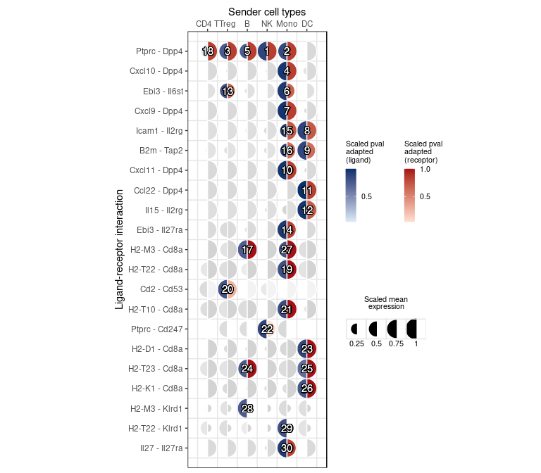

```r
legend_adjust <- c(0.8, 0.7)
make_mushroom_plot(prioritized_table,
                   top_n = 30,
                   show_all_datapoints = TRUE,
                   show_rankings = TRUE,
                   legend.title = element_text(size=8),
                   legend.text = element_text(size=8),
                   legend.key.size = unit(4, 'mm')) +
  theme(legend.justification = legend_adjust,
        axis.title.x = element_text(hjust = 0.25))
```

## Box 2. Prioritizing LR pairs across multiple receiver cell types

Because NicheNet runs on one receiver cell type at a time, prioritizing LR pairs across multiple receiver cell types requires rerunning the analysis for each cell type. Here, we use the wrapper function from Box 4 to run NicheNet for each T cell subtype as the receiver. Then, the relevant DE and expression tables for prioritization can be calculated for each receiver cell type. Finally, we concatenate all the tables and perform the prioritization.

```r
receiver_celltypes <- c("CD4 T", "CD8 T", "Treg")

# Run NicheNet for each receiver cell type
nichenet_outputs <- lapply(receiver_celltypes, function(receiver_ct){
  output <- nichenet_seuratobj_aggregate(receiver = receiver_ct,
                                         seurat_obj = seuratObj,
                                         condition_colname = "aggregate",
                                         condition_oi = condition_oi,
                                         condition_reference = condition_reference,
                                         sender = sender_celltypes,
                                         ligand_target_matrix = ligand_target_matrix,
                                         lr_network = lr_network,
                                         weighted_networks = weighted_networks,
                                         expression_pct = 0.05)
  # Add receiver cell type in ligand activity table
  output$ligand_activities$receiver <- receiver_ct
  return(output)
})
```

[output not shown]

```r
# Calculate prioritization criteria for each receiver cell type
info_tables <- lapply(nichenet_outputs, function(output) {
  lr_network_filtered <-  filter(lr_network[, c("from", "to")],
                                 from %in% output$ligand_activities$test_ligand &
                                 to %in% output$background_expressed_genes)

  generate_info_tables(seuratObj,
                       celltype_colname = "celltype",
                       senders_oi = sender_celltypes,
                       receivers_oi = unique(output$ligand_activities$receiver),
                       lr_network_filtered = lr_network_filtered,
                       condition_colname = "aggregate",
                       condition_oi = condition_oi,
                       condition_reference = condition_reference,
                       scenario = "case_control")
})
```

```
## condition_* is given. Only cells from that condition will be considered in cell type specificity calculation.
```

```
## condition_* is given. Only cells from that condition will be considered in cell type specificity calculation.
```

```
## condition_* is given. Only cells from that condition will be considered in cell type specificity calculation.
```

```r
# Combine the tables
info_tables_combined <- purrr::pmap(info_tables, bind_rows)
ligand_activities_combined <- purrr::map_dfr(nichenet_outputs, "ligand_activities")

# Calculate the prioritization table based on the combined tables
prior_table_combined <- generate_prioritization_tables(
  sender_receiver_info = distinct(info_tables_combined$sender_receiver_info),
  sender_receiver_de = info_tables_combined$sender_receiver_de,
  ligand_activities = ligand_activities_combined,
  lr_condition_de = distinct(info_tables_combined$lr_condition_de),
  scenario = "case_control")
```

## Box 3. Constructing your own prior model

Beecause the NicheNet prior model was constructed by integrating ligand-receptor, signaling, and gene regulatory databases, it is possible to replace each of these networks with external data sources. Constructing a customized prior model thus requires three directed networks, represented as data frames comprising three columns: `from`, `to`, and `source`. The `source` column contains the originating database of the interaction. As the reliability of each database can vary, we optimized the weights of each data source based on our validation procedure (as explained in Comparison with other methods). These optimized weights (`optimized_source_weights_df`), along with hyperparameters for model construction (`hyperparameter_list`), are provided in the NicheNet package. Key hyperparameters include correction factors for dominant hubs in the ligand-signaling and gene regulatory networks, as well as the central damping factor of the Personalized PageRank algorithm, the network propagation mechanism used to determine the ligand-target regulatory potential.

Note that the variable names of the networks have been changed from the manuscript in order to not overwrite the mouse networks, which will be used in the boxes below.

```r
# Download each part of the network
zenodo_path <- "https://zenodo.org/record/7074291/files/"
lr_network_human <- readRDS(url(paste0(zenodo_path, "lr_network_human_21122021.rds")))
sig_network_human <- readRDS(url(paste0(zenodo_path, "signaling_network_human_21122021.rds")))
gr_network_human <- readRDS(url(paste0(zenodo_path, "gr_network_human_21122021.rds")))

# Aggregate the individual data sources in a weighted manner to obtain
# a weighted integrated signaling network
weighted_networks_human <- construct_weighted_networks(
  lr_network = lr_network_human,
  sig_network = sig_network_human,
  gr_network = gr_network_human,
  source_weights_df = rename(optimized_source_weights_df, weight = median_weight))

# Downweigh the importance of signaling and gene regulatory hubs
# Use the optimized parameters of this
weighted_networks_human <- apply_hub_corrections(
  weighted_networks = weighted_networks_human,
  lr_sig_hub = hyperparameter_list[hyperparameter_list$parameter == "lr_sig_hub",]$median_weight,
  gr_hub = hyperparameter_list[hyperparameter_list$parameter == "gr_hub",]$median_weight
  )
```

In this example, we will calculate target gene regulatory potential scores for TNF and the combination TNF+IL6.

```r
# To compute it for all 1248 ligands (~1 min), use this instead:
# ligands <- as.list(unique(lr_network$from))

ligands <- list("TNF", c("TNF","IL6"))
ligand_target_matrix_human <- construct_ligand_target_matrix(
  weighted_networks = weighted_networks_human,
  ligands = ligands,
  algorithm = "PPR",
  damping_factor = hyperparameter_list[hyperparameter_list$parameter == "damping_factor",]$median_weight,
  ltf_cutoff = hyperparameter_list[hyperparameter_list$parameter == "ltf_cutoff",]$median_weight
  )
```

A frequent use case is one where users are interested in replacing the ligand-receptor network in NicheNet with those of expression permutation tools in order to make their results more comparable. To achieve this, we recommend employing LIANA (Dimitrov et al., 2022), a comprehensive CCC framework that integrates both resources and computational algorithms for ligand-receptor interaction inference. The `show_resources` function is used to check which resources are present in LIANA, and `select_resource` returns a data frame of the interactions in that resource. The `decomplexify` function of LIANA is necessary for this integration, as it separate receptors into their respective subunits. Note that unlike before, `source_weights_df` only represents unoptimized weights, where the weight of every data source is 1.

```r
if (!requireNamespace("liana", quietly=TRUE))
  devtools::install_github("saezlab/liana")

liana_db <- liana::decomplexify(liana::select_resource("CellPhoneDB")[[1]])
liana_db <- rename(liana_db, from = source_genesymbol, to = target_genesymbol)
liana_db$source <- "liana"
liana_db <- select(liana_db, from, to, source)

# Change source weights data frame (but in this case all source weights are 1)
source_weights <- add_row(source_weights_df,
                          source = "liana",
                          weight = 1, .before = 1)

# Construct weighted network as before
weighted_networks_liana <- construct_weighted_networks(
  lr_network = liana_db,
  sig_network = sig_network_human,
  gr_network = gr_network_human,
  source_weights_df = source_weights)
```

## Box 4. Wrapper functions

To streamline the NicheNet analysis, we introduce three wrapper functions that automate Steps 5-24 (without Step 15). These functions differ in how the features are extracted and correspond to the three experimental setups explained in Experimental design.

The function `nichenet_seuratobj_aggregate` is used for case-control scenarios, including the example case study in the Procedure. This function can be used to replicate the sender-focused analysis in the Procedure as follows:

```r
nichenet_output <- nichenet_seuratobj_aggregate(
  seurat_obj = seuratObj,
  receiver = "CD8 T",
  sender = c("CD4 T","Treg", "Mono", "NK", "B", "DC"),
  condition_colname = "aggregate",
  condition_oi = "LCMV",
  condition_reference = "SS",
  ligand_target_matrix = ligand_target_matrix,
  lr_network = lr_network,
  weighted_networks = weighted_networks)
```

```
## [1] "The RNA assay will be used for the analysis."
## [1] "Read in and process NicheNet's networks"
## [1] "Define expressed ligands and receptors in receiver and sender cells"
## [1] "Perform DE analysis in receiver cell"
## [1] "Perform NicheNet ligand activity analysis"
## [1] "Infer active target genes of the prioritized ligands"
## [1] "Infer receptors of the prioritized ligands"
## [1] "Perform DE analysis in sender cells"
```

```r
# Preview
names(nichenet_output)
```

```
##  [1] "ligand_activities"
##  [2] "top_ligands"
##  [3] "top_targets"
##  [4] "top_receptors"
##  [5] "ligand_target_matrix"
##  [6] "ligand_target_heatmap"
##  [7] "ligand_target_df"
##  [8] "ligand_expression_dotplot"
##  [9] "ligand_differential_expression_heatmap"
## [10] "ligand_activity_target_heatmap"
## [11] "ligand_receptor_matrix"
## [12] "ligand_receptor_heatmap"
## [13] "ligand_receptor_df"
## [14] "geneset_oi"
## [15] "background_expressed_genes"
```

The sender-agnostic approach can be run by setting `sender = "undefined"`.

The resulting object is a list comprising various components, including the gene set of interest and background genes that were used for the analysis (`geneset_oi` and `background_expressed_genes`), output from the ligand activity analysis (`ligand_activities`), targets and receptors corresponding to the identified ligands (`top_targets` and `top_receptors`), and visualizations (`ligand_target_heatmap`, `ligand_expression_dotplot`, `ligand_receptor_heatmap`, etc.).

Another wrapper function, `nichenet_seuratobj_cluster_de`, is used for comparing two cell types in the context of cell differentiation or localization. Note that the background gene set is fixed as the combination of expressed genes in both cell types. The code below shows how this function can be applied in the scenario in which cell type differentiation is driven by niche-specific factors:

```r
nichenet_seuratobj_cluster_de(
  seurat_obj = seurat_obj,
  receiver_affected = differentiated_celltype,
  receiver_reference = progenitor_cell,
  sender = niche_celltypes,
  ligand_target_matrix, lr_network,
  weighted_networks)
```

```r
nichenet_seuratobj_cluster_de(
  seurat_obj = seurat_obj,
  receiver_affected = differentiated_celltype,
  receiver_reference = progenitor_cell,
  condition_colname = "timepoint",
  condition_oi = "t1", condition_reference = "t0",
  sender = niche_celltypes,
  ligand_target_matrix,
  lr_network,
  weighted_networks)
```